# Regression Analysis

Team 5

21 March 2022

# Summary of the dataset

Hi there, welcome to our regression analysis dataset (`ListingsCovid`), which consists of 14 variables and captures 265 observations in total! To get a clear picture of our dataset, the following statistical summary of key variables used to carry out the regression analysis is provided. Also, the variables are filtered according to countries.

|  | AUT | BEL | CHE | CZE | DEU | DNK | ESP | GBR | GRC | ITA | NLD | Overall |
| --- | --- | --- | --- | --- | --- | --- | --- | --- | --- | --- | --- | --- |
|  | (N=13) | (N=26) | (N=11) | (N=19) | (N=35) | (N=12) | (N=57) | (N=35) | (N=7) | (N=37) | (N=13) | (N=265) |
| **Room Types** |  |  |  |  |  |  |  |  |  |  |  |  |
| 1 | 6 (46.2%) | 12 (46.2%) | 6 (54.5%) | 6 (31.6%) | 12 (34.3%) | 6 (50.0%) | 19 (33.3%) | 12 (34.3%) | 6 (85.7%) | 12 (32.4%) | 6 (46.2%) | 103 (38.9%) |
| 2 | 2 (15.4%) | 2 (7.7%) | 0 (0%) | 5 (26.3%) | 6 (17.1%) | 1 (8.3%) | 10 (17.5%) | 6 (17.1%) | 0 (0%) | 10 (27.0%) | 1 (7.7%) | 43 (16.2%) |
| 3 | 3 (23.1%) | 10 (38.5%) | 5 (45.5%) | 6 (31.6%) | 12 (34.3%) | 5 (41.7%) | 19 (33.3%) | 12 (34.3%) | 1 (14.3%) | 12 (32.4%) | 5 (38.5%) | 90 (34.0%) |
| 4 | 2 (15.4%) | 2 (7.7%) | 0 (0%) | 2 (10.5%) | 5 (14.3%) | 0 (0%) | 9 (15.8%) | 5 (14.3%) | 0 (0%) | 3 (8.1%) | 1 (7.7%) | 29 (10.9%) |
| **Average Price(log)** |  |  |  |  |  |  |  |  |  |  |  |  |
| Mean (SD) | 4.27 (0.501) | 4.45 (0.806) | 4.56 (0.574) | 7.63 (1.03) | 4.26 (0.680) | 6.44 (0.491) | 4.20 (0.848) | 4.60 (0.835) | 3.85 (0.232) | 4.51 (0.721) | 5.19 (0.657) | 4.73 (1.20) |
| Median [Min, Max] | 4.34 [3.37, 5.20] | 4.35 [3.22, 7.18] | 4.71 [3.69, 5.49] | 7.47 [5.69, 9.42] | 4.39 [3.09, 6.55] | 6.46 [5.69, 7.11] | 4.30 [2.89, 7.10] | 4.86 [2.71, 6.07] | 3.84 [3.51, 4.22] | 4.53 [2.40, 6.91] | 5.18 [4.36, 6.79] | 4.54 [2.40, 9.42] |
| **Availability** |  |  |  |  |  |  |  |  |  |  |  |  |
| Mean (SD) | 167 (102) | 152 (85.8) | 96.0 (88.8) | 193 (120) | 131 (83.1) | 91.9 (91.0) | 169 (87.8) | 146 (90.2) | 143 (52.7) | 199 (65.2) | 118 (49.3) | 155 (89.6) |
| Median [Min, Max] | 163 [0.818, 342] | 142 [0, 365] | 82.4 [0, 224] | 188 [0, 365] | 105 [0, 354] | 76.8 [0, 340] | 158 [0, 364] | 127 [0, 352] | 151 [71.0, 224] | 215 [0, 316] | 103 [43.0, 198] | 144 [0, 365] |
| **New Reviews per Quarter** |  |  |  |  |  |  |  |  |  |  |  |  |
| Mean (SD) | 0.954 (1.41) | 1.50 (1.76) | 9.80 (15.0) | 1.70 (3.05) | 3.97 (6.86) | 3.11 (4.77) | 7.24 (17.9) | 2.29 (2.56) | 1.57 (1.79) | 2.15 (2.68) | 7.58 (5.87) | 3.96 (9.75) |
| Median [Min, Max] | 0 [0, 4.57] | 1.00 [0, 6.58] | 5.83 [0, 53.0] | 0 [0, 12.0] | 1.50 [0, 32.9] | 1.50 [0, 15.0] | 1.00 [0, 121] | 2.00 [0, 9.25] | 1.00 [0, 4.49] | 1.08 [0, 9.59] | 5.53 [1.00, 18.9] | 1.18 [0, 121] |
| **Monthly Reviews** |  |  |  |  |  |  |  |  |  |  |  |  |
| Mean (SD) | 0.504 (0.401) | 0.602 (0.379) | 1.21 (1.62) | 0.947 (0.554) | 0.787 (0.687) | 0.627 (0.494) | 1.09 (1.15) | 0.675 (0.397) | 0.632 (0.315) | 0.781 (0.745) | 1.16 (0.732) | 0.840 (0.811) |
| Median [Min, Max] | 0.391 [0.0400, 1.32] | 0.558 [0.0800, 1.53] | 0.555 [0.145, 5.87] | 0.976 [0.0700, 2.41] | 0.493 [0.170, 3.08] | 0.422 [0.0800, 1.71] | 0.748 [0.0500, 6.79] | 0.570 [0.0800, 2.10] | 0.640 [0.207, 1.09] | 0.725 [0.0400, 4.49] | 1.01 [0.160, 2.50] | 0.631 [0.0400, 6.79] |
| **Weekly Covid Cases(log)** |  |  |  |  |  |  |  |  |  |  |  |  |
| Mean (SD) | 5.84 (4.18) | 7.53 (3.85) | 6.54 (3.65) | 8.09 (2.85) | 10.7 (1.59) | 8.71 (1.22) | 10.3 (2.91) | 10.9 (1.82) | 6.94 (3.68) | 7.70 (4.23) | 8.14 (3.71) | 9.00 (3.45) |
| Median [Min, Max] | 7.57 [0, 9.62] | 9.50 [0, 10.6] | 7.90 [0, 9.52] | 6.81 [3.40, 11.3] | 10.5 [8.48, 12.9] | 8.74 [6.80, 10.1] | 11.0 [0, 12.3] | 12.0 [7.85, 12.6] | 8.18 [0, 9.62] | 9.80 [0, 11.3] | 9.96 [0, 10.3] | 9.95 [0, 12.9] |

# Histogram of average price

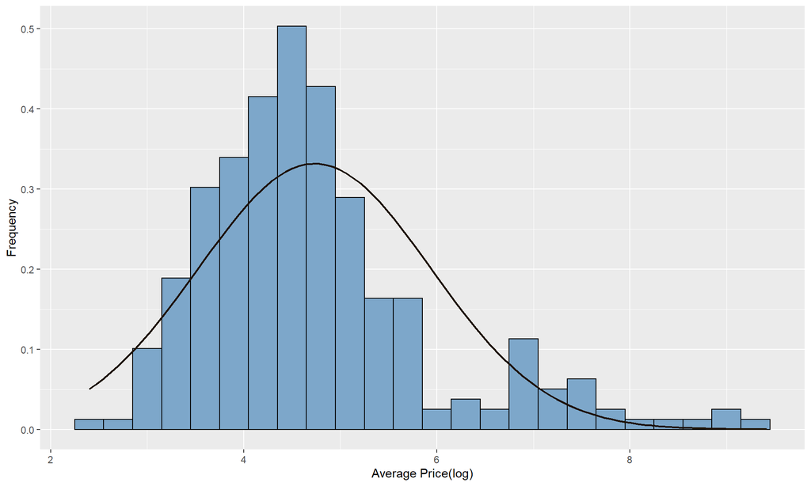

# Scatterplot of average price vs weekly COVID-19 cases

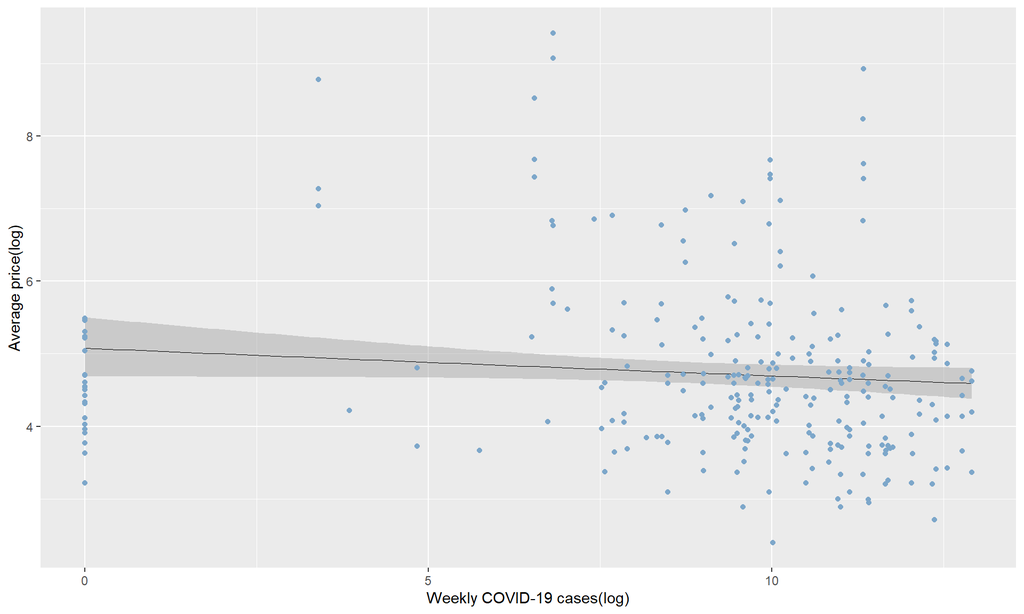

# Scatterplot of average price vs weekly COVID-19 cases by country

Since the previous scatterplot shows no correlation between the average price and weekly COVID-19 cases, we decided to investigate whether the country may affect the results. The finding from the second scatterplot is as follows: the correlations do differ per country – showing either a positive or negative linear relationship between the two variables, while still, quite a few countries such as the Netherlands, Germany, and Austria show no correlation.

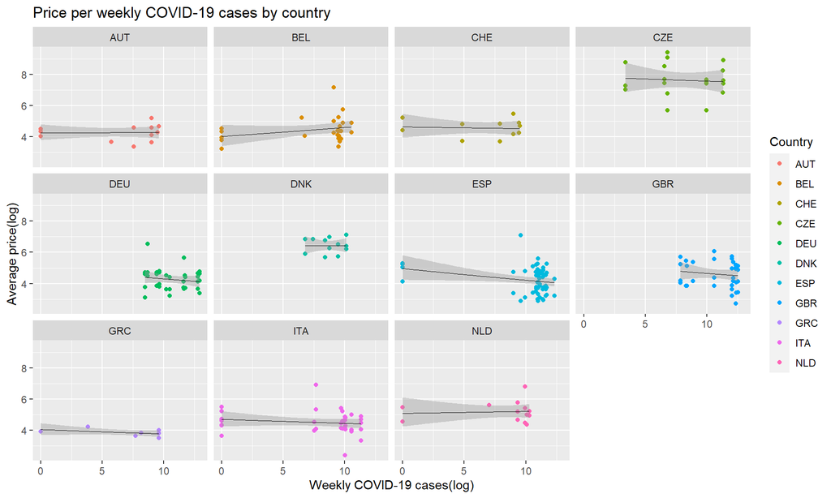

# Model 1: Simple regression

*Note*: at first we log both the dependent and independent variables; however,since the weekly COVID cases appear to be more significant without log, we simply use log only on our dependent variable `log_price`.

|  | Estimate | Std. Error | t value | Pr(>\|t\|) |
| --- | --- | --- | --- | --- |
| **(Intercept)** | 4.871 | 0.08784 | 55.46 | 3.842e-147 |
| **weekly_count** | -2.402e-06 | 8.539e-07 | -2.813 | 0.005276 |

Fitting linear model: log_price ~ weekly_count

| Observations | Residual Std. Error | $R^2$ | Adjusted $R^2$ |
| --- | --- | --- | --- |
| 265 | 1.187 | 0.02921 | 0.02552 |

# Model 2: Multiple Regression

Now for the multiple regression, our choice of added variables chiefly depends on which variables improved the R square and overall the model. In comparison to the simple regression model, the R square in Multiple Regression shows that model fits better to our observations!

|  | Estimate | Std. Error | t value | Pr(>\|t\|) |
| --- | --- | --- | --- | --- |
| **(Intercept)** | 5.333 | 0.1845 | 28.9 | 1.458e-82 |
| **weekly_count** | -1.747e-06 | 8.047e-07 | -2.171 | 0.03085 |
| **room_type2** | 0.2884 | 0.2136 | 1.35 | 0.1782 |
| **room_type3** | -0.8425 | 0.1544 | -5.456 | 1.147e-07 |
| **room_type4** | -1.319 | 0.2319 | -5.687 | 3.523e-08 |
| **minimum_nights** | -0.00818 | 0.004777 | -1.712 | 0.08802 |
| **reviews_per_month** | 0.1485 | 0.1379 | 1.076 | 0.2828 |
| **number_of_reviews_ltm** | -0.02135 | 0.01167 | -1.829 | 0.06852 |
| **availability_365** | -0.0006275 | 0.0007998 | -0.7846 | 0.4334 |

Fitting linear model: log_price ~ weekly_count + room_type + minimum_nights + reviews_per_month + number_of_reviews_ltm + availability_365

| Observations | Residual Std. Error | $R^2$ | Adjusted $R^2$ |
| --- | --- | --- | --- |
| 265 | 1.064 | 0.2417 | 0.218 |

In terms of multicollinearity, all analysed variables have a GVIF below 10. According to the rule of thumb, there is no problem with multicollinearity for any of the variables.

*Model 2: Checking Multicollinearity*

[output not shown]

As for heteroskedasticity, the residuals in model 2 have an unequal variance across all the independent variables; overall indicating heteroskedasticity.

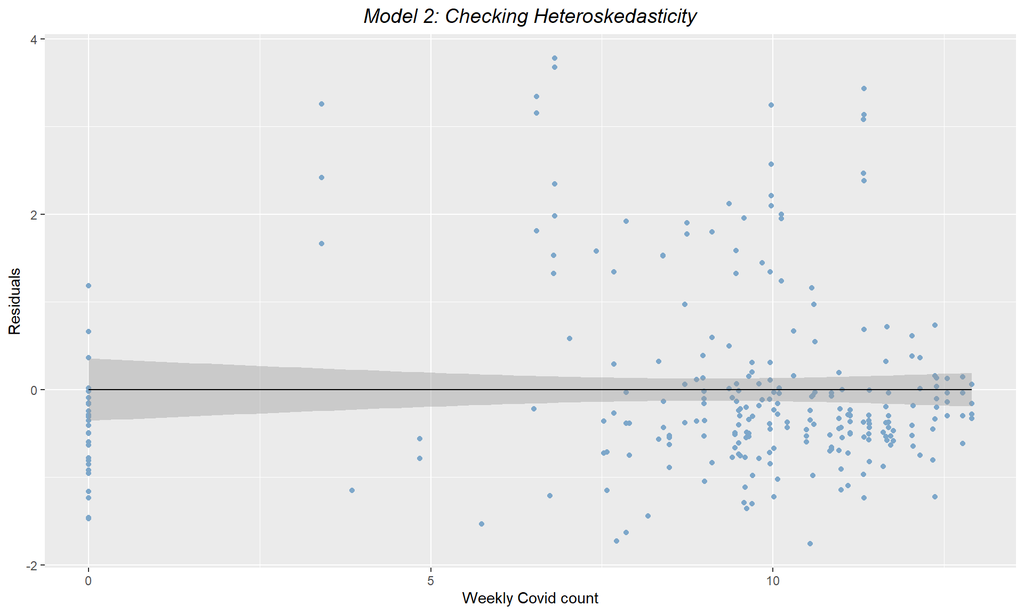

# Model 3: Regression with added interactions

We have added the interaction between weekly_count and room_type to model 2 to check if it would improve the model fit. By comparing the R squared from model 2 and model 3, it is evident that the the R squared has barely increased.

|  | Estimate | Std. Error | t value | Pr(>\|t\|) |
| --- | --- | --- | --- | --- |
| **(Intercept)** | 5.27 | 0.195 | 27.03 | 1.503e-76 |
| **weekly_count** | -6.551e-07 | 1.421e-06 | -0.461 | 0.6452 |
| **room_type2** | 0.3861 | 0.2504 | 1.542 | 0.1243 |
| **room_type3** | -0.7973 | 0.1853 | -4.304 | 2.402e-05 |
| **room_type4** | -1.151 | 0.2881 | -3.993 | 8.54e-05 |
| **minimum_nights** | -0.008074 | 0.004795 | -1.684 | 0.09347 |
| **reviews_per_month** | 0.1643 | 0.1412 | 1.164 | 0.2456 |
| **number_of_reviews_ltm** | -0.02209 | 0.01197 | -1.845 | 0.06621 |
| **availability_365** | -0.0006317 | 0.0008028 | -0.787 | 0.432 |
| **weekly_count:room_type2** | -1.684e-06 | 2.195e-06 | -0.7673 | 0.4436 |
| **weekly_count:room_type3** | -9.663e-07 | 2.016e-06 | -0.4792 | 0.6322 |
| **weekly_count:room_type4** | -2.43e-06 | 2.299e-06 | -1.057 | 0.2917 |

Fitting linear model: log_price ~ weekly_count * room_type + minimum_nights + reviews_per_month + number_of_reviews_ltm + availability_365

| Observations | Residual Std. Error | $R^2$ | Adjusted $R^2$ |
| --- | --- | --- | --- |
| 265 | 1.067 | 0.2455 | 0.2127 |

The variable minimum_nights has the lowest GVIF, so it has the weakest correlation. Whereas,the highest is for the interaction between weekly_count and room_type. Interaction terms naturally produce higher multicollinearity. All analysed variables have a GVIF below 10. According to the rule of thumb,there is no problem with multicollinearity for any of the variables.

*Model 3: Checking multicollinearity*

|  | GVIF | Df | GVIF^(1/(2*Df)) |
| --- | --- | --- | --- |
| weekly_count | 3.428129 | 1 | 1.851521 |
| room_type | 4.030474 | 3 | 1.261516 |
| minimum_nights | 1.071518 | 1 | 1.035141 |
| reviews_per_month | 3.041876 | 1 | 1.744098 |
| number_of_reviews_ltm | 3.160231 | 1 | 1.777704 |
| availability_365 | 1.199211 | 1 | 1.095085 |
| weekly_count:room_type | 9.853335 | 3 | 1.464189 |

The residuals in model 3 have an unequal variance across all the independent variables, indicating heteroskedasticity.

[figure not shown]

# Conclusion